# Part II - Airline Lateness Report

## by Diego Merino

## Investigation Overview

This investigation was performed on the January 2022 data of the National Bureau of Transportation Statistics that gathers information about the lateness in flights by US carriers.

## Dataset Overview

The Dataset contains data of all flights performed by US Carriers in the month of January 2022. It specifies the delay on departure, on arrival, the distance and time in the air, as well as a break down on the reason for the delay.

This breakwdown has 5 components:

- Carrier Delay: Delays caused by problems in the airline's operation.
- National Air System Delay: Delays related to the management of airspace and ground operations.
- Weather delay: Delays related to weather phenomena.
- Security Delay: Delays caused by security, TSA and other agencies.
- Late Aircraft Delay: Delays caused by the aircraft intended arriving late from the previous flight.

## How is Traffic Distributed in the US?

We can see a clear distribution of traffic in the US on the following map.

- Traffic is heavily distributed in both East and West Coast.
- The main Airports by traffic are
  - Dallas
  - Denver
  - Chicago
  - Atlanta
- This airports are hubs for the main US carriers. They use a Hub and Spoke model that redirects regional traffic through main hubs, where flights to the main cities in the US are operated.

Make this Notebook Trusted to load map: File -> Trust Notebook

[interactive chart not shown]

## How Are Delays distributed?

We applied a logarithmic transformation to the data, since it was extremely right skewed.

- We can observe a bi-modal distribution with two spikes around:
  - 15 minutes
  - 30-45 Minutes
- The graph also shows how the vast majority of delays are between 15 and 100 minutes.

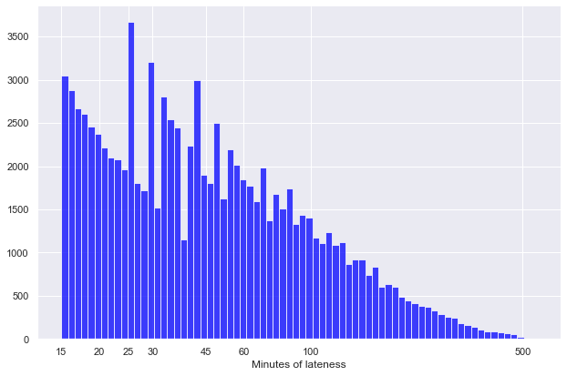

## Who causes the greater delays?

- Carriers are responsible for an average 30 minutes of delay directly caused by their operations.
- Late aircrafts are the second leading factor affecting delays.
  - Delays are mostly a chain reaction, and late aircraft can have a huge impact on the process. All the Airline processes are handled in a timely fashion. Every minute of delay puts a strain on the structure leading to more delays.
  - All of the other factors can feedback into a plane becoming late. In this case, we can think of the other categories leading into an original delay, that will become a Late Aircraft Delay for the rest of the flights that an aircraft performs in a day.
- Weather and Security produced less than 5 minutes in average delays.
- National Air System caused an average 10 minutes delay.

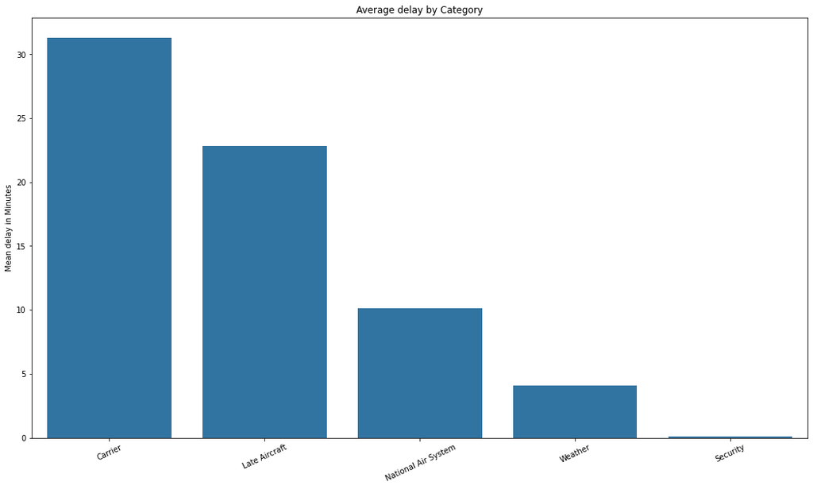

## Which airlines have a worst on-time ratio?

- Smaller airlines tend to have a more balanced equilibrium between groups (for example American Eagle and Midwest Airlines have an almost equal balance).
- Bigger airlines such as Delta, Skywest, Southwest have a distribution more skewed to bigger delays.
- From the last two graphs we can see, that the bigger the operative and concentration of operations, the bigger the delays.

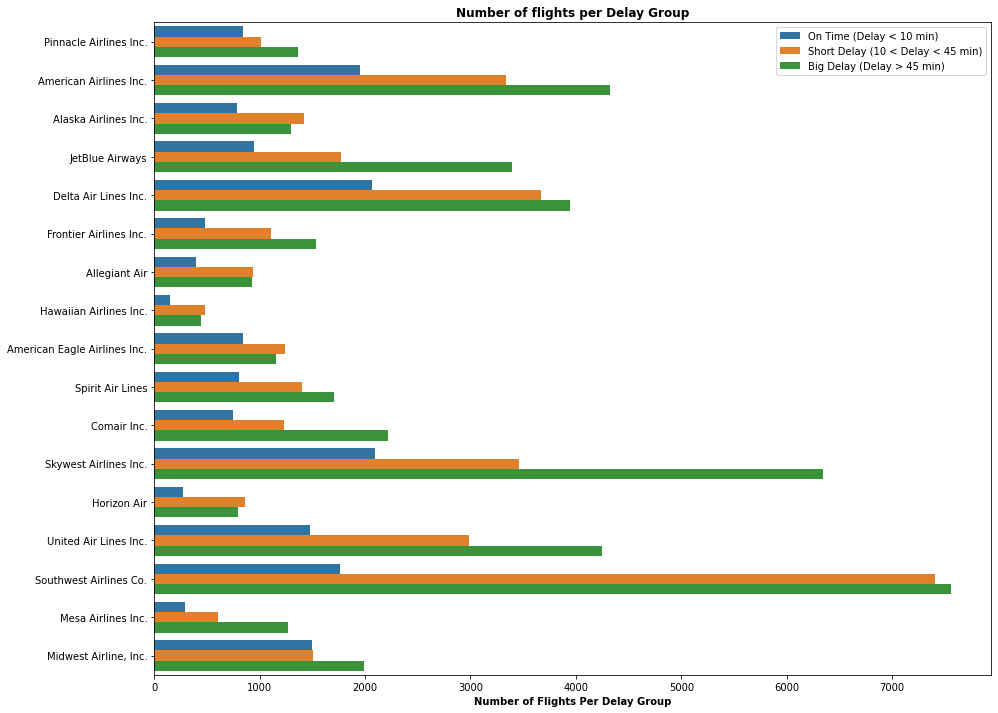

## Is there a relationship between short, medium and long haul flights and lateness?

We divided the flights in terms of Air Time:

- Short Haul: 0 to 180 minutes.
- Medium Haul: 180 to 360 minutes.
- Long Haul: More than 360 minutes.

Key takeaways:

- The longer the flight, the shorter the average delay.
- Short haul flights have the more severe distribution of delays.
  - This confirms the data on the second slide, where we defined the cascading effects that delays can have.

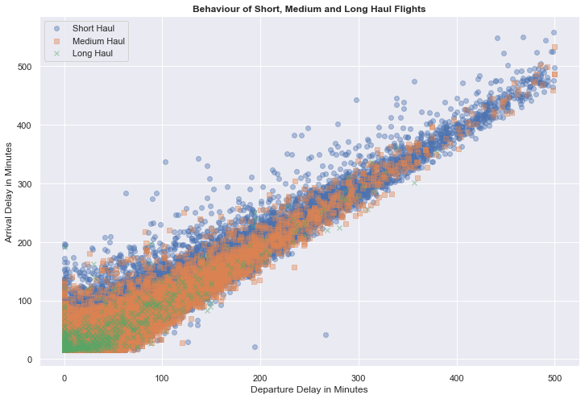

#### How are the types of delays related between them?

- We can see a 95% correlation between Arrival Delay and Departure Delay.
- Carrier and Late Aircraft delay are the most correlated with Departure Delay.
- Air Service Delay is positively correlated with Arrival Delays and negatively correlated with departure delays:
  - This exemplifies the complexity and frailness of arrival procedures.
- Security delay is not correlated and seems to not have affected air traffic in the month of January in the USA.

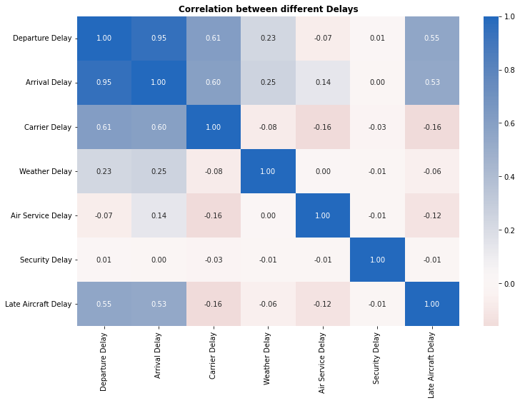